# Module 9. Time-varying predictors and nonlinear change

Slides

## What this module covers

- Time-invariant and time-varying covariates
- Within-person and between-person associations (person-mean centring)
- Time-varying covariates that are affected by treatment (mediation)
- Unequal intervals: actual time, not visit number
- Curved trajectories: polynomial, piecewise, spline, GAMM
- What we can and cannot conclude causally

**Simulated data**

All examples use simulated data from fictional studies. Results illustrate methods; they are not empirical findings.

# Time-varying covariates

## Some covariates change at every visit

| id | arm | age | bmi | month | steps | sbp |
| --- | --- | --- | --- | --- | --- | --- |
| W001 | EP | 69 | 32.8 | 0.00 | 4.5 | 150 |
| W001 | EP | 69 | 32.8 | 1.09 | 6.5 | 148 |
| W001 | EP | 69 | 32.8 | 2.95 | 7.7 | 133 |
| W001 | EP | 69 | 32.8 | 6.04 | 7.2 | 140 |
| W001 | EP | 69 | 32.8 | 9.68 | 7.0 | 132 |
| W001 | EP | 69 | 32.8 | 11.13 | 8.2 | 132 |

- **Time-invariant:** arm, age, sex, BMI (repeated on every row)
- **Time-varying:** steps (thousands/day), time itself

## The programmes change steps: steps is partly an outcome

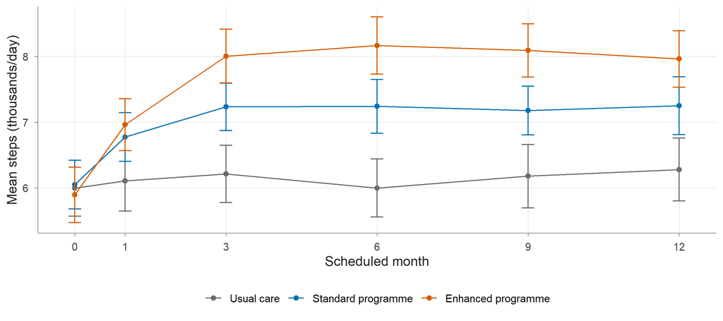

# Within and between

## Two different questions about steps and blood pressure

- **Between-person:** do people who usually walk more have lower SBP?
- **Within-person:** when a person walks more than usual, is their SBP lower than usual?

Truth (simulation only): between -1.5, within -0.6 mmHg per 1,000 steps/day.

A single coefficient for `steps` blends the two.

## Person-mean centring splits the covariate in two

$$y_{ij} = \mathbf{x}_{ij}^\top\boldsymbol\beta + \beta_W(s_{ij} - \bar s_i) + \beta_B(\bar s_i - \bar s) + b_{0i} + b_{1i}t_{ij} + \varepsilon_{ij}$$

```r
walk <- walk |>
  group_by(id) |> mutate(steps_pm = mean(steps)) |> ungroup() |>
  mutate(steps_wc = steps - steps_pm,                          # within
         steps_gm = steps_pm - mean(steps_pm[!duplicated(id)])) # between
```

Contextual effect: $\beta_C = \beta_B - \beta_W$ (enter raw `steps` + person mean).

## Fitting the three versions

```r
m_naive  <- lmer(sbp ~ steps + visit_f * arm + (1 + month | id),
                 data = walk, control = lmer_ctrl)
m_wb     <- lmer(sbp ~ steps_wc + steps_gm + visit_f * arm + (1 + month | id),
                 data = walk, control = lmer_ctrl)
m_wb_adj <- lmer(sbp ~ steps_wc + steps_gm + visit_f * arm +
                   age10 + sex + bmi_c + (1 + month | id),
                 data = walk, control = lmer_ctrl)
m_ctx    <- lmer(sbp ~ steps + steps_gm + visit_f * arm +
                   age10 + sex + bmi_c + (1 + month | id),
                 data = walk, control = lmer_ctrl)
```

## The within-person effect is stable; the between-person effect needs adjustment

| Model | Term | Estimate (95% CI) | Truth |
| --- | --- | --- | --- |
| Naive | steps | -0.80 (-1.03 to -0.56) | none |
| Centred | within | -0.62 (-0.87 to -0.37) | -0.6 |
| Centred | between | -1.91 (-2.53 to -1.29) | -1.5 |
| Centred + age, sex, BMI | within | -0.62 (-0.87 to -0.37) | -0.6 |
| Centred + age, sex, BMI | between | -1.69 (-2.30 to -1.08) | -1.5 |
| Contextual + age, sex, BMI | contextual | -1.07 (-1.73 to -0.41) | -0.9 |

## Reading the contextual effect

> Among participants walking the same number of steps this week, those who **usually** walk 1,000 more steps a day have SBP about 1.1 mmHg lower.
- Tests whether between and within effects differ
- Same fit as the within/between version, different labels

## Try it

Workbook exercise 1: person-mean centring of steps, naive vs decomposed coefficients, and the effect of adjusting for BMI.

# Mediation

## Adjusting for steps changes the treatment estimand

```r
m_primary <- lmer(sbp ~ visit_f * arm + (1 + month | id),
                  data = walk, control = lmer_ctrl)
m_steps   <- lmer(sbp ~ steps_wc + visit_f * arm + (1 + month | id),
                  data = walk, control = lmer_ctrl)
```

| Contrast | Primary (total effect) | Adjusted for steps | Truth: total / not via steps |
| --- | --- | --- | --- |
| SP vs UC | -5.4 (-8.2 to -2.6) | -4.8 (-7.6 to -2.0) | -4.6 / -4.0 |
| EP vs UC | -9.0 (-11.8 to -6.1) | -7.9 (-10.8 to -5.1) | -8.1 / -7.0 |

## Total and direct effects answer different questions

- **Total effect** (primary model): what randomisation to a programme does. Protected by randomisation.
- **Direct effect** (adjusted for steps): the effect not acting through walking. Needs no confounding of steps and SBP, which randomisation does not guarantee.
- Formal mediation with time-varying mediators: Module 13

# Time scales

## Visit number is not time

```r
m_actual <- lmer(sbp ~ month * arm + (1 + month | id), data = walk, control = lmer_ctrl)
m_sched  <- lmer(sbp ~ month_sched * arm + (1 + month_sched | id), data = walk,
                 control = lmer_ctrl)
m_visit  <- lmer(sbp ~ I(visit - 1) * arm + (1 + I(visit - 1) | id), data = walk,
                 control = lmer_ctrl)
sapply(list(actual = m_actual, sched = m_sched, visit = m_visit),
       function(m) fixef(m)[6])        # EP vs UC slope difference
```

```
#>       actual.month:armEP  sched.month_sched:armEP visit.I(visit - 1):armEP
#>                  -0.7235                  -0.7290                  -1.9231
```

## KIDNEY: irregular visits, more frequent when eGFR is low

```r
kidney <- kidney |> group_by(id) |> arrange(years, .by_group = TRUE) |>
  mutate(visit_no = row_number() - 1) |> ungroup()
mk_years <- lmer(egfr ~ years + (1 + years | id), data = kidney, control = lmer_ctrl)
mk_visit <- lmer(egfr ~ visit_no + (1 + visit_no | id), data = kidney, control = lmer_ctrl)
c(per_year = fixef(mk_years)[2], per_visit = fixef(mk_visit)[2])
```

```
#>     per_year.years per_visit.visit_no
#>             -2.586             -1.063
```

## Try it

Workbook exercise 2: time scales in WALK and KIDNEY.

# Nonlinear trajectories

## The true change is fast, then levels off

$$\mu(t) - \mu(0) = -A\{1 - \exp(-t/2)\}$$

Three ways to bend a line inside `lmer()`:

- **Quadratic:** $t$, $t^2$
- **Piecewise linear:** $t$, $(t - 3)_+$ (knot at month 3)
- **Natural spline:** `splines::ns(month, df = 3)`

All are linear in the parameters.

## Fitting the candidates by ML

```r
fit_ml <- function(f) lmer(f, data = walk, control = lmer_ctrl, REML = FALSE)
m_lin  <- fit_ml(sbp ~ month * arm + (1 + month | id))
m_quad <- fit_ml(sbp ~ (month + I(month^2)) * arm + (1 + month | id))
m_pw   <- fit_ml(sbp ~ (month + month_p3) * arm + (1 + month | id))
m_ns   <- fit_ml(sbp ~ splines::ns(month, df = 3) * arm + (1 + month | id))
m_cat  <- fit_ml(sbp ~ visit_f * arm + (1 + month | id))
```

## Fitted shapes against the truth

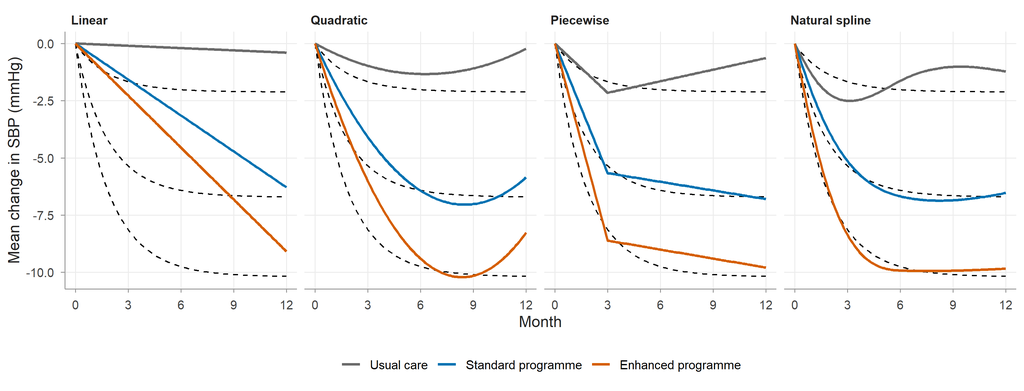

## Comparing the fits

| Model | Parameters | AIC | BIC | SP vs UC, m12 | EP vs UC, m12 |
| --- | --- | --- | --- | --- | --- |
| Linear | 10 | 13435 | 13491 | -5.88 | -8.68 |
| Quadratic | 13 | 13326 | 13399 | -5.63 | -8.03 |
| Piecewise | 13 | 13317 | 13390 | -6.16 | -9.16 |
| Natural spline | 16 | 13307 | 13396 | -5.30 | -8.62 |
| Categorical | 22 | 13315 | 13437 | -5.38 | -8.97 |

Truth at month 12: SP −4.6, EP −8.1.

## Piecewise coefficients are rates for each phase

| Arm | Months 0-3 (mmHg/month) | After month 3 (mmHg/month) |
| --- | --- | --- |
| Usual care | -0.72 | 0.17 |
| Enhanced programme | -2.87 | -0.13 |

## Try it

Workbook exercise 3: quadratic, piecewise and spline trajectories.

# GAMMs

## A GAMM lets the data choose the smoothness

$$y_{ij} = \beta_0 + \alpha_1\text{SP}_i + \alpha_2\text{EP}_i + f_{a(i)}(t_{ij}) + b_{0i} + b_{1i}t_{ij} + \varepsilon_{ij}$$

- $f_a$: penalised spline for each arm; roughness penalty estimated by REML
- Effective degrees of freedom (edf): 1 = straight line
- Smooths are centred: arm coefficients are **average** differences

## Fitting a GAMM in mgcv

```r
g_walk <- gamm(sbp ~ arm + s(month, by = arm, k = 5),
               random = list(id = ~ 1 + month), data = walk, method = "REML")
summary(g_walk$gam)$s.table
```

```
#>                  edf Ref.df      F p-value
#> s(month):armUC 2.822  2.822  2.926  0.1083
#> s(month):armSP 3.230  3.230 26.516  0.0000
#> s(month):armEP 3.550  3.550 52.411  0.0000
```

Same model with random-effect smooths (independent intercepts and slopes):

```r
bam(sbp ~ arm + s(month, by = arm, k = 5) + s(idf, bs = "re") +
      s(idf, month, bs = "re"), data = walk, method = "fREML")   # idf = factor(id)
```

## GAMM trajectories with intervals

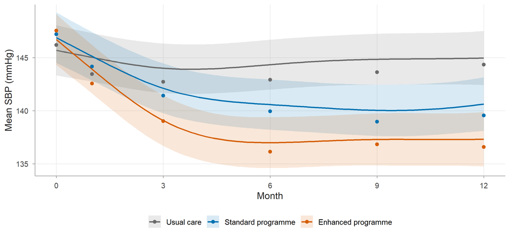

## GAMM for KIDNEY: accelerating decline, steeper with diabetes

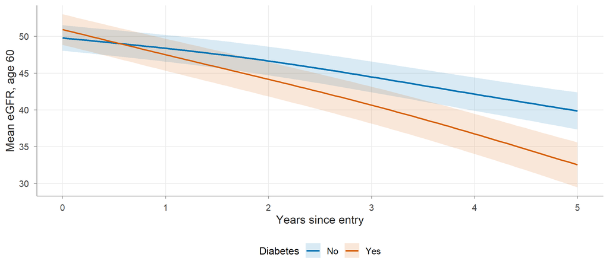

## Try it

Workbook exercise 4: a GAMM for WALK and the month-12 contrast from predictions.

# Causal interpretation

## Within-person does not mean causal

- **Time-varying confounding:** illness lowers steps and raises SBP
- **Reverse causation:** high SBP prompts advice to walk more
- **Mediation:** steps lies between programme and SBP

Randomisation protects the arm comparison, not the steps association.

## Say what you estimated

- Causal: “1,000 more steps a day **lowers** SBP by 0.6 mmHg”
- Associational: “SBP was 0.6 mmHg lower at visits when participants walked 1,000 more steps than their own average”

Use the second unless the design justifies the first.

## Summary

- Decompose time-varying covariates into within and between parts
- Do not adjust trial treatment effects for post-randomisation mediators
- Use actual time; irregular visits are fine in a mixed model
- Piecewise for interpretable phases, splines and GAMMs for shape; categorical time for the visit-specific estimand
- Associations with time-varying covariates are not causal effects by default